# Projeto Integrador - Exercicio 04

Adelvan Lima

```r
library(readr)
library(descr)
```

Olá, pessoal. Este é o quarto exercício do nosso Projeto Integrador deste semestre. Vamos continuar trabalhando com o banco de dados do Enade 2014. Para leitura dos dados, use:

```r
enade14 <- read_csv2("https://raw.githubusercontent.com/neylsoncrepalde/introducao_ao_r/master/dados/enade_2014_amostra.csv")
```

## Exercícios:

## 1. Extraia a média, a mediana, mínimo, máximo, variância e desvio padrão da idade para todos os alunos da nossa amostra aleatória.

```r
# média da variável referente a idade da amostra
mean(enade14$nu_idade)
```

```
## [1] 29.8941
```

```r
# mediana da variável referente a idade da amostra
median(enade14$nu_idade)
```

```
## [1] 27
```

```r
# menor valor da variável referente a idade da amostra
min(enade14$nu_idade)
```

```
## [1] 18
```

```r
# maior valor da variável referente a idade da amostra
max(enade14$nu_idade)
```

```
## [1] 73
```

```r
# variância da variável referente a idade da amostra
var(enade14$nu_idade)
```

```
## [1] 72.35032
```

```r
# desvio padrão da variável referente a idade da amostra
sd(enade14$nu_idade)
```

```
## [1] 8.505899
```

## 2. Elabore uma tabela de frequência da quantidade de alunos por sexo. Corrija a variável caso alguma categoria esteja “sobrando”.

```r
sexo_alunos <- enade14$tp_sexo

# tratamento da variável
sexo_alunos[sexo_alunos == "N"] <- NA

freq(sexo_alunos[!is.na(sexo_alunos)] ,plot = FALSE)
```

```
## sexo_alunos[!is.na(sexo_alunos)]
##       Frequência Percentual
## F           5744      57.45
## M           4254      42.55
## Total       9998     100.00
```

## 3. Agora extraia a média, a mediana, mínimo, máximo, variância e desvio padrão da idade para cada categoria de sexo. Exiba os mesmos resultados com um gráfico.

```r
# idades dos participantes do sexo feminino
idade_feminina <- enade14$nu_idade[enade14$tp_sexo == "F"]

# idades dos participantes do sexo masculino
idade_masculina <- enade14$nu_idade[enade14$tp_sexo == "M"]
```

### Participantes do sexo feminino

```r
# média da variável referente a idade feminina
mean(idade_feminina)
```

```
## [1] 30.57329
```

```r
# mediana da variável referente a idade feminina
median(idade_feminina)
```

```
## [1] 28
```

```r
# menor valor da variável referente a idade feminina
min(idade_feminina)
```

```
## [1] 18
```

```r
# maior valor da variável referente a idade feminina
max(idade_feminina)
```

```
## [1] 72
```

```r
# variância da variável referente a idade feminina
var(idade_feminina)
```

```
## [1] 79.85742
```

```r
# desvio padrão da variável referente a idade feminina
sd(idade_feminina)
```

```
## [1] 8.936298
```

### Participantes do sexo masculino

```r
# média da variável referente a idade masculina
mean(idade_masculina)
```

```
## [1] 28.96803
```

```r
# mediana da variável referente a idade masculina
median(idade_masculina)
```

```
## [1] 27
```

```r
# menor valor da variável referente a idade masculina
min(idade_masculina)
```

```
## [1] 18
```

```r
# maior valor da variável referente a idade masculina
max(idade_masculina)
```

```
## [1] 73
```

```r
# variância da variável referente a idade masculina
var(idade_masculina)
```

```
## [1] 60.61172
```

```r
# desvio padrão da variável referente a idade masculina
sd(idade_masculina)
```

```
## [1] 7.785353
```

### Representação gráfica da relação entre as variáveis idade e sexo

#### Representação gráfica da distribuição das idades das participantes do sexo feminino

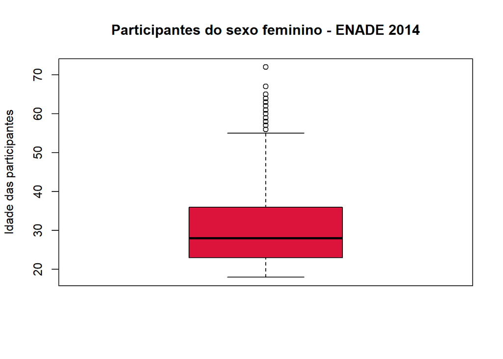

```r
boxplot(idade_feminina,
        col = "#DC143C",
        main = "Participantes do sexo feminino - ENADE 2014",
        ylab = "Idade das participantes")
```

#### Representação gráfica da distribuição das idades dos participantes do sexo masculino

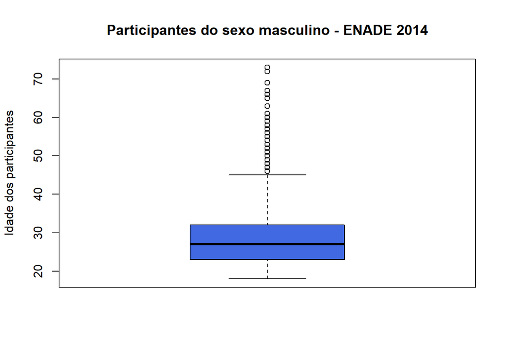

```r
boxplot(idade_masculina,
        col = "#4169E1",
        main = "Participantes do sexo masculino - ENADE 2014",
        ylab = "Idade dos participantes")
```

## 4. Agora extraia a média, a mediana, mínimo, máximo, variância e desvio padrão da idade para cada categoria de cor/raça. Exiba os mesmos resultados com um gráfico.

```r
# idades dos participantes cuja cor/raça foi declarada brancos
idade_brancos <- enade14$nu_idade[enade14$qe_i2 == "a"]

# idades dos participantes cuja cor/raça foi declarada negros
idade_negros <- enade14$nu_idade[enade14$qe_i2 == "b"]

# idades dos participantes cuja cor/raça foi declarada pardos
idade_pardos <- enade14$nu_idade[enade14$qe_i2 == "c"]

# idades dos participantes cuja cor/raça foi declarada amarelos
idade_amarelos <- enade14$nu_idade[enade14$qe_i2 == "d"]

# idades dos participantes cuja cor/raça foi declarada indigenas
idade_indigenas <- enade14$nu_idade[enade14$qe_i2 == "e"]
```

### Brancos

```r
# média da variável referente a idade de declarados brancos
mean(idade_brancos, na.rm = TRUE)
```

```
## [1] 29.11463
```

```r
# mediana da variável referente a idade de declarados brancos
median(idade_brancos, na.rm = TRUE)
```

```
## [1] 26
```

```r
# menor valor da variável referente a idade de declarados brancos
min(idade_brancos, na.rm = TRUE)
```

```
## [1] 18
```

```r
# maior valor da variável referente a idade de declarados brancos
max(idade_brancos, na.rm = TRUE)
```

```
## [1] 72
```

```r
# variância da variável referente a idade de declarados brancos
var(idade_brancos, na.rm = TRUE)
```

```
## [1] 70.21313
```

```r
# desvio padrão da variável referente a idade de declarados brancos
sd(idade_brancos, na.rm = TRUE)
```

```
## [1] 8.379328
```

### Negros

```r
# média da variável referente a idade de declarados negros
mean(idade_negros, na.rm = TRUE)
```

```
## [1] 30.90258
```

```r
# mediana da variável referente a idade de declarados negros
median(idade_negros, na.rm = TRUE)
```

```
## [1] 28
```

```r
# menor valor da variável referente a idade de declarados negros
min(idade_negros, na.rm = TRUE)
```

```
## [1] 19
```

```r
# maior valor da variável referente a idade de declarados negros
max(idade_negros, na.rm = TRUE)
```

```
## [1] 73
```

```r
# variância da variável referente a idade de declarados negros
var(idade_negros, na.rm = TRUE)
```

```
## [1] 82.98265
```

```r
# desvio padrão da variável referente a idade de declarados negros
sd(idade_negros, na.rm = TRUE)
```

```
## [1] 9.109481
```

### Pardos

```r
# média da variável referente a idade de declarados pardos
mean(idade_pardos, na.rm = TRUE)
```

```
## [1] 30.3668
```

```r
# mediana da variável referente a idade de declarados pardos
median(idade_pardos, na.rm = TRUE)
```

```
## [1] 28
```

```r
# menor valor da variável referente a idade de declarados pardos
min(idade_pardos, na.rm = TRUE)
```

```
## [1] 19
```

```r
# maior valor da variável referente a idade de declarados pardos
max(idade_pardos, na.rm = TRUE)
```

```
## [1] 66
```

```r
# variância da variável referente a idade de declarados pardos
var(idade_pardos, na.rm = TRUE)
```

```
## [1] 70.85972
```

```r
# desvio padrão da variável referente a idade de declarados pardos
sd(idade_pardos, na.rm = TRUE)
```

```
## [1] 8.417822
```

### Amarelos

```r
# média da variável referente a idade de declarados amarelos
mean(idade_amarelos, na.rm = TRUE)
```

```
## [1] 29.15504
```

```r
# mediana da variável referente a idade de declarados amarelos
median(idade_amarelos, na.rm = TRUE)
```

```
## [1] 27
```

```r
# menor valor da variável referente a idade de declarados amarelos
min(idade_amarelos, na.rm = TRUE)
```

```
## [1] 20
```

```r
# maior valor da variável referente a idade de declarados amarelos
max(idade_amarelos, na.rm = TRUE)
```

```
## [1] 53
```

```r
# variância da variável referente a idade de declarados amarelos
var(idade_amarelos, na.rm = TRUE)
```

```
## [1] 49.1164
```

```r
# desvio padrão da variável referente a idade de declarados amarelos
sd(idade_amarelos, na.rm = TRUE)
```

```
## [1] 7.008309
```

### Indigenas

```r
# média da variável referente a idade de declarados indigenas
mean(idade_indigenas, na.rm = TRUE)
```

```
## [1] 30.42308
```

```r
# mediana da variável referente a idade de declarados indigenas
median(idade_indigenas, na.rm = TRUE)
```

```
## [1] 29.5
```

```r
# menor valor da variável referente a idade de declarados indigenas
min(idade_indigenas, na.rm = TRUE)
```

```
## [1] 20
```

```r
# maior valor da variável referente a idade de declarados indigenas
max(idade_indigenas, na.rm = TRUE)
```

```
## [1] 61
```

```r
# variância da variável referente a idade de declarados indigenas
var(idade_indigenas, na.rm = TRUE)
```

```
## [1] 73.54595
```

```r
# desvio padrão da variável referente a idade de declarados indigenas
sd(idade_indigenas, na.rm = TRUE)
```

```
## [1] 8.575894
```

### Representação gráfica da relação entre as variáveis idade e cor/raça

#### Representação gráfica da distribuição das idades dos participantes declarados brancos

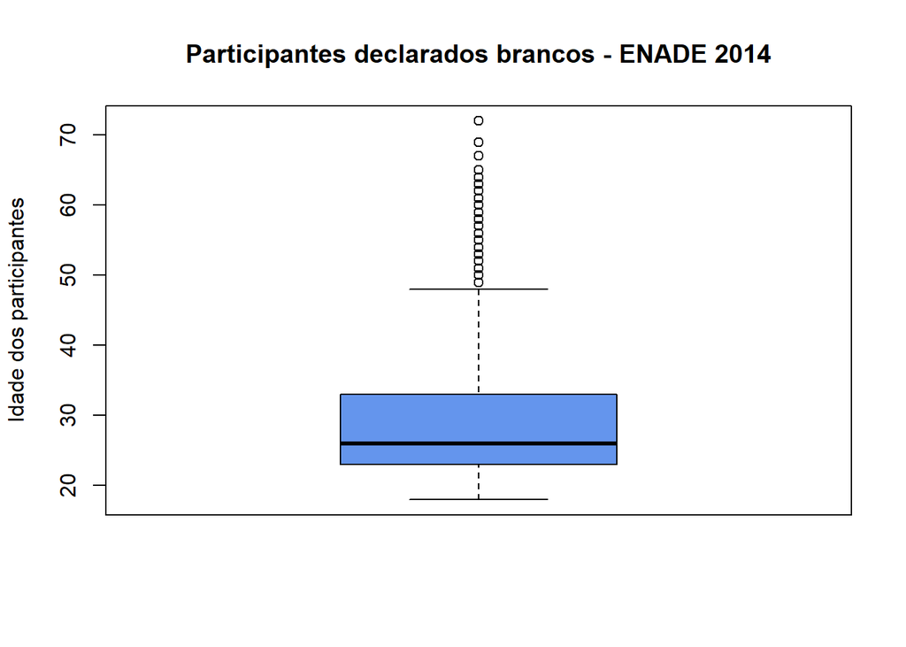

```r
boxplot(idade_brancos,
        col = "#6495ED",
        main = "Participantes declarados brancos - ENADE 2014",
        ylab = "Idade dos participantes")
```

#### Representação gráfica da distribuição das idades dos participantes declarados negros

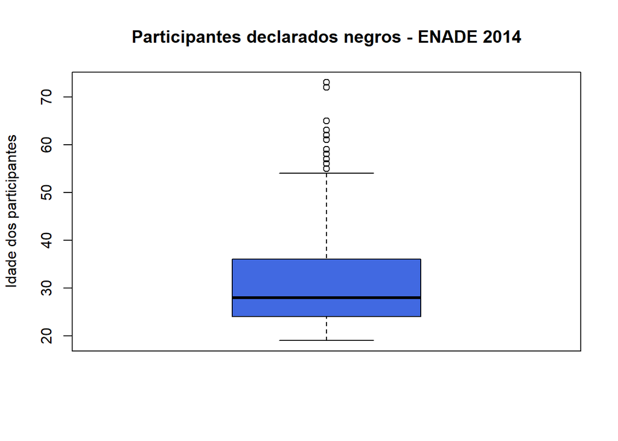

```r
boxplot(idade_negros,
        col = "#4169E1",
        main = "Participantes declarados negros - ENADE 2014",
        ylab = "Idade dos participantes")
```

#### Representação gráfica da distribuição das idades dos participantes declarados pardos

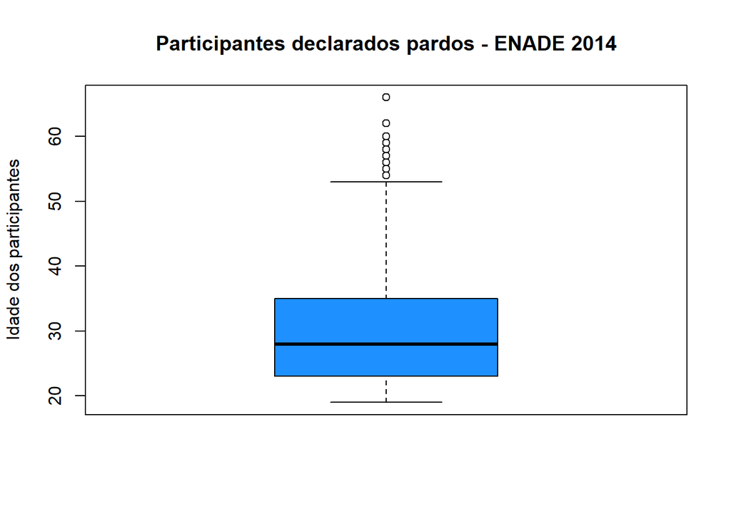

```r
boxplot(idade_pardos,
        col = "#1E90FF",
        main = "Participantes declarados pardos - ENADE 2014",
        ylab = "Idade dos participantes")
```

#### Representação gráfica da distribuição das idades dos participantes declarados amarelos

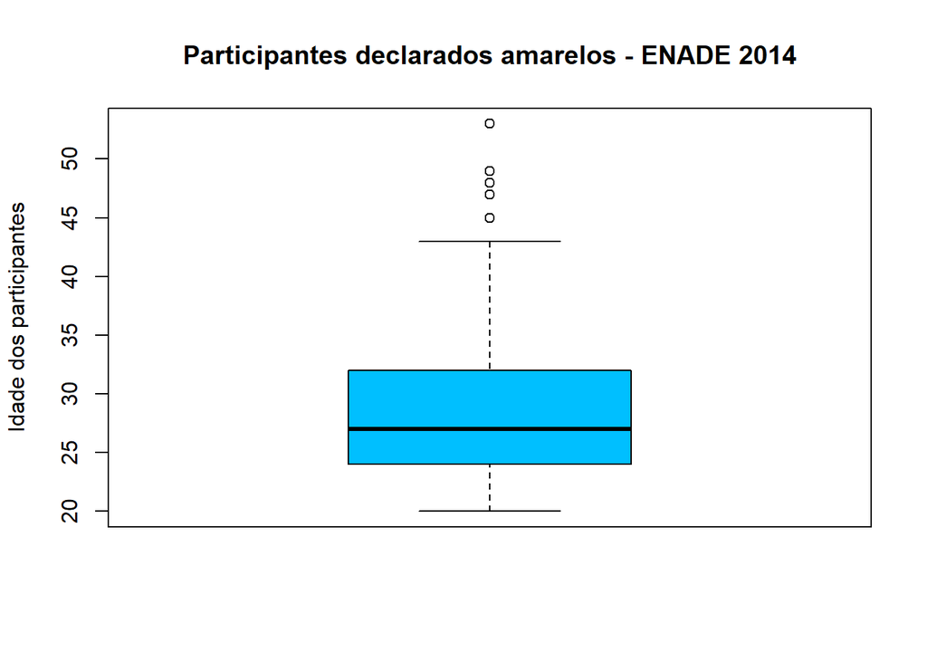

```r
boxplot(idade_amarelos,
        col = "#00BFFF",
        main = "Participantes declarados amarelos - ENADE 2014",
        ylab = "Idade dos participantes")
```

#### Representação gráfica da distribuição das idades dos participantes declarados indigenas

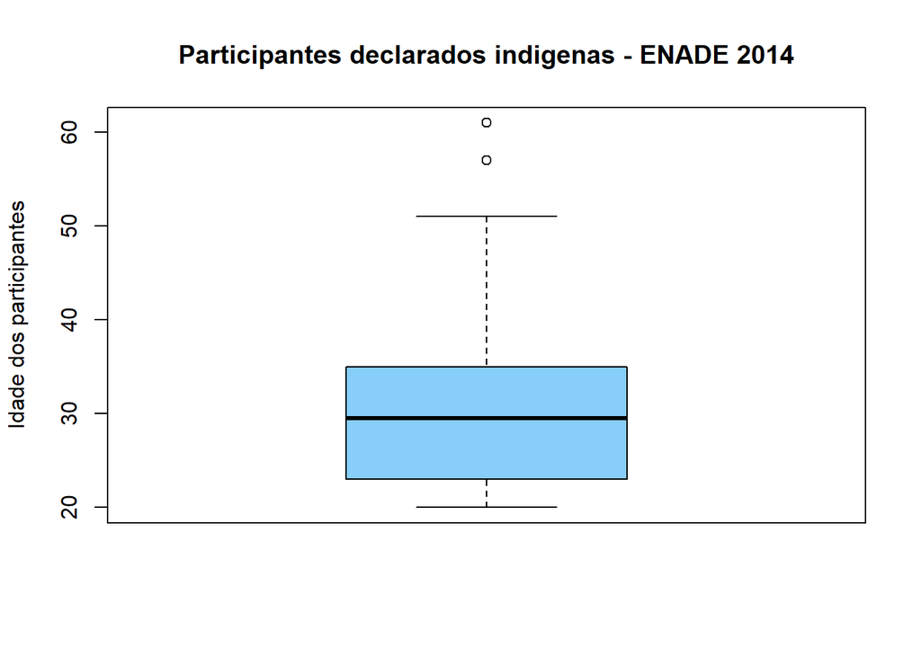

```r
boxplot(idade_indigenas,
        col = "#87CEFA",
        main = "Participantes declarados indigenas - ENADE 2014",
        ylab = "Idade dos participantes")
```

## 5. Verifique a distribuição de alunos por região do país. Exiba uma tabela de frequências e um gráfico.

### Tratamento dos dados na variável

```r
# cria a coluna região na base de dados do ENADE 2014 em que estamos trabalhando
enade14$regiao <- enade14$co_regiao_curso

# atribui os estados de acordo com o código usado na aplicação do ENADE 2014
enade14$regiao[enade14$regiao == 1] = "Norte"
enade14$regiao[enade14$regiao == 2] = "Nordeste"
enade14$regiao[enade14$regiao == 3] = "Sudeste"
enade14$regiao[enade14$regiao == 4] = "Sul"
enade14$regiao[enade14$regiao == 5] = "Centro Oeste"
```

### Representação gráfica e a tabela da distribuição dos alunos participantes por região

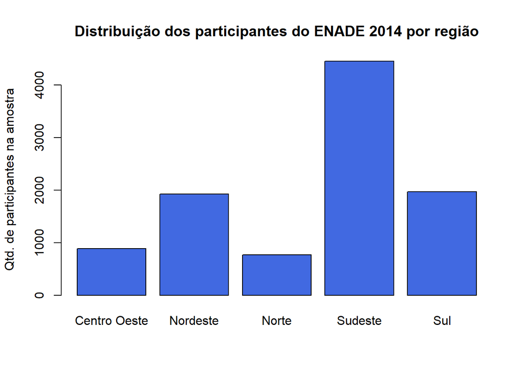

```
## enade14$regiao
##              Frequência Percentual
## Centro Oeste        884       8.84
## Nordeste           1927      19.27
## Norte               770       7.70
## Sudeste            4451      44.51
## Sul                1968      19.68
## Total             10000     100.00
```

```r
# Representação gráfica da distribuição dos alunos por região do país
freq(enade14$regiao,
     main = "Distribuição dos participantes do ENADE 2014 por região",
     ylab = "Qtd. de participantes na amostra",
     col = c("#4169E1", "#4169E1", "#4169E1", "#4169E1", "#4169E1"))
```

## 6. Vamos investigar a associação entre a renda e a cor. Faça uma tabela cruzada entre essas duas variáveis.

```r
# criação das variáveis auxiliares
enade14$cor_raca <- enade14$qe_i2
enade14$distribuicao_renda <- enade14$qe_i8

# preenchimento da variavel cor_raca
enade14$cor_raca[enade14$cor_raca == "a"] <- "Brancos"
enade14$cor_raca[enade14$cor_raca == "b"] <- "Negros"
enade14$cor_raca[enade14$cor_raca == "c"] <- "Pardos"
enade14$cor_raca[enade14$cor_raca == "d"] <- "Amarelos"
enade14$cor_raca[enade14$cor_raca == "e"] <- "Indigenas"

# preenchimento da variavel distribuicao de renda
enade14$distribuicao_renda <- enade14$qe_i8
enade14$distribuicao_renda[enade14$distribuicao_renda == "a"] <- "[até 1,5]"
enade14$distribuicao_renda[enade14$distribuicao_renda == "b"] <- "[de 1,5 a 3]"
enade14$distribuicao_renda[enade14$distribuicao_renda == "c"] <- "[de 3 a 4,5]"
enade14$distribuicao_renda[enade14$distribuicao_renda == "d"] <- "[de 4,5 a 6]"
enade14$distribuicao_renda[enade14$distribuicao_renda == "e"] <- "[de 6 a 10]"
enade14$distribuicao_renda[enade14$distribuicao_renda == "f"] <- "[de 10 a 30]"
enade14$distribuicao_renda[enade14$distribuicao_renda == "g"] <- "[acima de 30]"

# cria uma tabela comparando as variaveis renda e cor
comparacao<- table(enade14$cor_raca, enade14$distribuicao_renda)
print(comparacao)
```

```
##
##             [acima de 30] [até 1,5] [de 1,5 a 3] [de 10 a 30] [de 3 a 4,5]
##   Amarelos              3        27           33           16           15
##   Brancos              63       549         1141          453         1005
##   Indigenas             1        28           29            5            8
##   Negros                1       231          309           25          172
##   Pardos               14       760          933          132          553
##
##             [de 4,5 a 6] [de 6 a 10]
##   Amarelos            13          22
##   Brancos            661         734
##   Indigenas            4           3
##   Negros              86          69
##   Pardos             285         311
```

## Desafios:

## 1. Guarde a tabela que vc programou no exercício 6 num objeto. Existe algum teste estatístico para sabermos se existe associação entre essas variáveis? Rode o teste e apresente os resultados. (nível easy)

```r
# Futuramente, pretendo voltar neste desafio e atualizá-lo.
```

## 2. Comente os resultados (nível medium)

```r
# Futuramente, pretendo voltar neste desafio e atualizá-lo.
```

## 3. Verifique a variável categoria administrativa da IES no dicionário de variáveis. Recategorize a variável em uma binária: “Pública e Privada”. Crie uma nova variável para armezenar esses dados. (nível hard)

```r
# Futuramente, pretendo voltar neste desafio e atualizá-lo.
```

## 4. Você consegue descobrir qual foi a média da nota geral dos alunos de pedagogia do Izabela Hendrix no Enade 2014? (nível Chuck Norris)

```r
# Futuramente, pretendo voltar neste desafio e atualizá-lo.
```